# The Society for Conservation Biology

[Conservation Biology](https://conbio.onlinelibrary.wiley.com/journal/15231739)

[Volume 20, Issue 1](https://conbio.onlinelibrary.wiley.com/toc/15231739/2006/20/1) p. 3-13

[figure not shown]

*Conservation Education*

# A Graduate Education Framework for Tropical Conservation and Development

## Un Marco de Educación de Posgrado para Conservación y Desarrollo Tropical

[KAREN A. KAINER](https://conbio.onlinelibrary.wiley.com/action/doSearch?ContribAuthorRaw=KAINER%2C+KAREN+A),

kkainer@latam.ufl.edu

[MARIANNE SCHMINK](https://conbio.onlinelibrary.wiley.com/action/doSearch?ContribAuthorRaw=SCHMINK%2C+MARIANNE),

[HANNAH COVERT](https://conbio.onlinelibrary.wiley.com/action/doSearch?ContribAuthorRaw=COVERT%2C+HANNAH),

[JOHN RICHARD STEPP](https://conbio.onlinelibrary.wiley.com/action/doSearch?ContribAuthorRaw=STEPP%2C+JOHN+RICHARD),

[EMILIO M. BRUNA](https://conbio.onlinelibrary.wiley.com/action/doSearch?ContribAuthorRaw=BRUNA%2C+EMILIO+M),

[JONATHAN L. DAIN](https://conbio.onlinelibrary.wiley.com/action/doSearch?ContribAuthorRaw=DAIN%2C+JONATHAN+L),

[SANTIAGO ESPINOSA](https://conbio.onlinelibrary.wiley.com/action/doSearch?ContribAuthorRaw=ESPINOSA%2C+SANTIAGO),

[SHOANA HUMPHRIES](https://conbio.onlinelibrary.wiley.com/action/doSearch?ContribAuthorRaw=HUMPHRIES%2C+SHOANA),

First published: 23 January 2006

https://doi.org/10.1111/j.1523-1739.2006.00356.x

## Abstract

**Abstract:** *Conventional graduate training related to tropical conservation and development has typically separated the two fields, with students focusing on either conservation from the perspective of the biophysical sciences or development as an extension of the social sciences. On entering the workforce, however, graduates find they are required to work beyond disciplinary boundaries to address the complex interconnectivity between biological conservation and human well-being. We devised a framework for graduate education that broadens students' skill sets to learn outside their immediate disciplines and think in terms of linked socioecological systems, work in teams, communicate in nonacademic formats, and reflect critically on their own perspectives and actions. The University of Florida's Tropical Conservation and Development program has adopted a learning and action platform that blends theory, skills, and praxis to create an intellectual, social, and professionally safe space where students, faculty, and other participants can creatively address the complex challenges of tropical conservation and development. This platform operates within a nondegree-granting program and includes core courses that are taught by a team of biophysical and social scientists. It incorporates a range of alternative learning spaces such as student-led workshops, retreats, visiting professionals, practitioner experiences, and a weekly student-led seminar that collectively encourage students and faculty to enhance their skills and systematically and thoroughly reflect on program activities. Challenges to the described approach include increased service demands on faculty, a redefinition of research excellence to include effective and equitable collaboration with host-country partners, and the trade-offs and uncertainties inherent in more collaborative, interdisciplinary research. Despite these challenges, growing interdisciplinary programs, coupled with adaptive educational approaches that emphasize learning and action networks of students, faculty, and field partners, provide the best hope for responding to the emerging challenges of tropical conservation and development.*

## Introduction

When asked whether an independent India would follow the British pattern of development, Mahatma Ghandi replied, “It took Britain half the resources of the planet to achieve this prosperity. How many planets would a country like India require?” The challenge of addressing the seemingly contradictory objectives of environmental conservation and economic development is particularly urgent in tropical countries, which often have both high biodiversity and some of the world's lowest standards of living. In tropical America, rapidly expanding human populations, widespread poverty, and economies strongly dependent on natural resources make these regions and their inhabitants particularly sensitive to these coupled environmental and socioeconomic dynamics.

This complex, interrelated, and rapidly changing world has motivated universities to rethink the educational experience of society's future leaders. In the United States, and perhaps more so in developing countries, public investment in higher education is predicated on a collective expectation of a return of knowledge and technology for the benefit of society (Lubchenco 1998). Some have articulated that a new social contract is in order for science in general (Lubchenco 1998) and for institutions of higher education in particular (Duderstadt 1999).

Conventional graduate training related to tropical conservation and development has typically separated the two fields, with students focusing on either conservation from the perspective of the biophysical sciences or development as an extension of the social sciences. Separating these fields has its academic merits and is desirable in some cases. Many graduates, however, find that on entering the workforce they are required to work beyond the boundaries of the discipline in which they were trained, addressing the complex interconnectivity between biological conservation and human well-being. Fundamentally, developing strong leadership from and for tropical regions is crucial for addressing this monumental challenge. Accordingly, universities have been called on to rethink and reshape the education of scientists and professionals (COSEPUP 1995). What types of knowledge and skills do graduates need to address effectively the connections between the conservation of natural systems and economic development? What types of graduate programs might best prepare professionals for this integrated reality? These kinds of questions have been raised in recent articles in *Conservation Biology* that focus on conservation science and policy (Meffe 1998) and on graduate education and training in temperate and tropical conservation (Bonine et al. 2003; Inouye & Brewer 2003).

We devised a framework that addresses the theoretical, methodological, and practical challenges to graduate training for tropical conservation and development. The framework has been applied in an academic program, and we offer concrete examples of this application and current student perspectives on program effectiveness.

## Reshaping Graduate Education for Tropical Conservation and Development

Traditional graduate training, particularly at the Ph.D. level, has concentrated on producing disciplinary researchers, often modeled after the faculty members under whom they apprentice (Magner 2000). As the workplace has become more interdisciplinary, global, and collaborative, however, graduates are required to be technically proficient, broadly trained, and capable of working in teams. More than ever, there is also an emphasis on working toward a more humanistic and sustainable society, one in which the “academy” is obligated to generate knowledge and to apply it to concrete problems (Mendes dos Santos 2002).

With these changes, there has been a call not to just “tweak graduate education around the edges” but to reshape it completely (COSEPUP 1995; Duderstadt 1999; Golde & Gallagher 1999). In the United States, this desired change has received enough attention to precipitate substantial financial support, such as that of the National Science Foundation's Integrated Graduate Education and Research Traineeship (IGERT) program. The IGERT program expresses an intention “to catalyze a *cultural change in graduate education*, for students, faculty, and institutions, by establishing innovative new models for graduate education and training in a fertile environment for collaborative research that transcends traditional disciplinary boundaries” (NSF 2005, emphasis added; see also Zarin et al. 2003).

This demand for reformed graduate education is driven in part by the organizations that employ graduates from conservation and resource management programs. Recent surveys indicated they need team members with cross-disciplinary and disciplinary depth and skills in languages, communication, leadership, negotiation, and policy analysis (Jacobson 1990; Reid et al. 2002; Bonine et al. 2003). Fundraising, monitoring, and evaluation skills were also high on the list, perhaps a clear reflection of the importance of answering to donors. That human interaction and communication skills are at least as important as disciplinary knowledge is not surprising (Jacobson 1990; Cannon et al. 1996) because conservation and development practitioners work with a remarkably diverse group of stakeholders, ranging from indigenous community members to corporate CEOs. The ability to effectively elicit and present ideas, negotiate varying interests, run meetings, and deliver successful workshops can make or break a conservation or development program, regardless of technical merit. This wide range of competencies mirrors the breadth of the challenge of achieving biodiversity conservation success.

Scientists are increasingly called on to communicate in different ways, such as explaining complex ideas to policy makers and the general public (Lubchenco 1998; Meffe 1998). Although the traditional currency of peer-reviewed publications still holds the greatest weight within the scientific community, the need to communicate effectively with other societal sectors is now considered a highly desirable skill, if not a fundamental professional responsibility. The formal teaching of ethics and responsible conduct of research have also emerged as important features in a new culture of graduate education and research (Bradshaw & Bekoff 2001; NSF 2005) as has an increased emphasis on granting respect to professional colleagues and students (Grabau 1998, 1999). These themes are related to the increased desire to work well collaboratively and respond more responsibly to the larger society.

The desire to reform graduate education is not limited to the United States. Abeledo (2003) calls for the design of programs in developing countries to promote problem-oriented research rather than selecting research themes or projects a priori with the hope that promising results can be “transferred.” A problem-oriented, hands-on approach requires teamwork, communication, and interdisciplinary analyses—skills that resonate with job demands placed on conservation and development professionals. This active attempt to “solve problems” also rings true with the new social contract for science and scientists. The abilities required of those attempting to identify and solve problems collaboratively, however, contrast sharply with the skills set of a conventional disciplinary graduate student working alone to investigate a narrowly defined research topic.

This broader view of graduate training begets multiple challenges for education reformers. Within the university these include increased service demands on faculty, inflexible administrative structures that impede cross-departmental interactions, and trade-offs and uncertainties inherent to more collaborative, interdisciplinary research. In addition, relatively few academics or employers are willing to give up disciplinary depth to accommodate multidisciplinary breadth, and COSEPUP (1995) cautions reformers to not unduly increase the time required to obtain a degree. Students and young scientists are apprehensive that time spent on problem solving may not be rewarded within the academic system and that efforts to articulate research relevance to the larger society could be perceived as advocacy and met with disapproval from within and outside academia (Jacobson & Jacobson 1997).

These valid concerns corroborate the suggestion that a sweeping cultural change in graduate education may be necessary for scientists to address twenty-first century problems effectively. How can a new skills set be incorporated into an already full curriculum? In what ways can interdisciplinary breadth be obtained without sacrificing disciplinary depth? How might graduate programs better prepare graduates to become forward-thinking leaders prepared to improve human well-being while conserving the diversity of biological wealth in the tropics? The University of Florida's Tropical Conservation and Development (TCD) program has been wrestling with these issues for more than 15 years, and the program's framework for managing and adapting a graduate program is a product of these years of experience.

## Framework for Tropical Conservation and Development Learning and Action

The TCD program, housed at the University of Florida's Center for Latin American Studies, was established in the 1980s. The program does not grant degrees; rather, it offers an interdisciplinary certificate that functions much like a minor. It also provides a supportive learning environment and fellowships and research grants for M.S. and Ph.D. students (enrolled in 20 participating academic units on campus) who are pursuing careers in tropical conservation and development (http://www.latam.ufl.edu/tcd). Approximately one-half of all participating students are from Latin America and other tropical countries, and many of these are supported with TCD fellowships. Between 1988 and 2005, the TCD fellowship competition has awarded 248 academic-year fellowships to 145 entering and continuing students from 27 countries.

The TCD mission is to advance biodiversity conservation, sustainable resource management, and the welfare of rural people in the tropics through interdisciplinary graduate education, research, and collaborative learning and practice. The program draws on participation of current TCD faculty and students and on a broad network of partners, including alumni, mostly in Latin America but also in tropical regions worldwide.

Over the years, the TCD program has received substantial funding from private foundations such as the John D. and Catherine T. MacArthur Foundation, the William and Flora Hewlett Foundation, and the Gordon and Betty Moore Foundation. Students have received complementary support from faculty grants, departmental teaching assistantships, Fulbright and OAS fellowships, and fellowships from foreign government agencies such as CONACYT (Consejo Nacional de Ciencia y Tecnología) (Mexico) and CNPq (Conselho Nacional de Desenvolvimento Cientifico e Tecnológico) (Brazil). In 2000 the program secured a $4 million endowment from the Ford Foundation and the state of Florida, ensuring continuation of the program in perpetuity. This funding, coupled with TCD's relatively long academic history, has facilitated programmatic experimentation and growth and consolidation of program goals and philosophy.

### TCD Approach

The TCD approach has evolved over two decades of adapting a graduate program to the constantly changing fields of tropical conservation and development within the bounds of an academic institution. The framework that has emerged builds on traditional disciplinary foundations, integrates past and present student experiences, and embraces collaborative learning and action for tropical conservation and development (Fig. 1). At the heart of the framework is a learning and action platform, a space for program participants to interact and innovate. The platform consists of multiple opportunities to develop and put into practice the competencies required of flexible, forward-thinking leaders. The best way we have found to keep up with this dynamic is to embrace an adaptive learning approach, one that we are constantly seeking to articulate and improve. Writing, publishing, and receiving feedback on this paper is another step in that learning process.

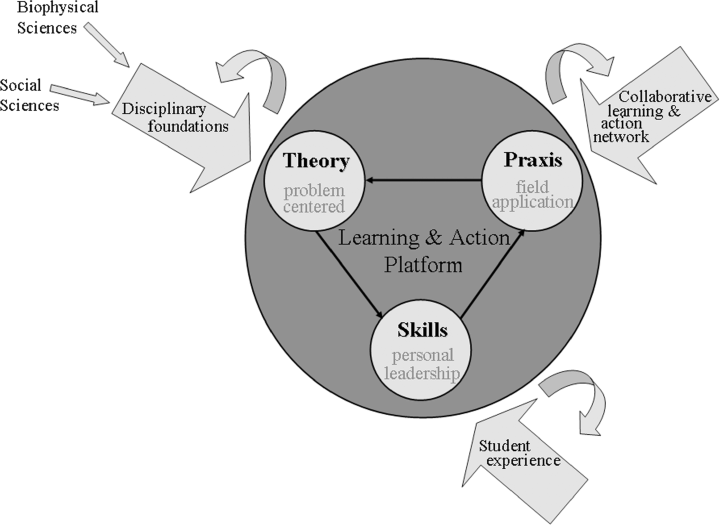

**Figure 1**

*A graduate education framework based on the Tropical Conservation and Development program's experiences.*

The program operates under the premise that the fields of conservation and development are coupled, mandating an approach that embraces a wide range of diverse and critical perspectives. With its combined focus on these two fields, TCD provides support to biologists concerned with ecological systems and nonhuman species and to social scientists interested in policy development and human well-being. Paradoxically, biological scientists often see TCD as a “social science” program, whereas social scientists comment that TCD's emphasis is more on conservation than on development. The program derives strength from the creation of an environment in which students and faculty can interact outside their disciplinary boundaries and cultures. Students typically carry out disciplinary research for their degrees but situate their work within a broader context of conservation and development issues, often incorporating cross-disciplinary components or applied activities with local partners.

The core TCD learning and action platform is supported by an interconnected triad of theory, skills, and praxis (Fig. 1). For TCD these three dimensions translate into three specific foci that interact and suffuse all TCD graduate activities such that training (1) is problem centered, innovating across disciplines to focus on real world problems; (2) strengthens personal leadership, building on student experience and enhancing communication and critical self-reflection skills; and (3) converges in field application, linking graduate training and research to a collaborative network of others involved in the policies and practice of tropical conservation and development.

#### PROBLEM-CENTERED FOCUS

The theoretical leg of the TCD learning and action platform draws on the disciplinary depth of diverse students and faculty, encouraging transdisciplinary exploration within a problem-oriented approach. The constituency for this intellectual exchange is three primary groups. (1) Six core faculty provide diverse expertise in, for example, development studies, gender, plant and animal interactions, ethnoecology, tropical forestry, academic program management, adult learning, and conflict and collaboration management. Three core faculty hold joint, tenure-accruing appointments in TCD and their corresponding disciplinary units. Significantly, two others are not under a conventional professorial track and thus have greater flexibility to provide student services and develop and administer program directives. (2) More than 70 faculty affiliates and their associated 20 academic units across campus are involved, as are (3) current masters and doctoral students with a range of sociocultural backgrounds and experiences.

The TCD students are matriculated in more than a dozen social science and biophysical science units ranging from anthropology to zoology and in interdisciplinary units such as the Center for Latin American Studies and the School of Natural Resources and the Environment. The distribution of the program's 243 alumni, of which 58% earned masters' degrees and the remainder doctorates, illustrates the breadth of academic units represented (Fig. 2). The current cohort is 88 students, of which more than half are doctoral students. The overarching goal is for students to achieve fluency in their home discipline and competency in a range of other complementary disciplines. Students are encouraged to let the problem at hand guide the choice of applicable disciplines rather than let the discipline determine the limits of the problem itself (cf. Abel & Stepp 2003).

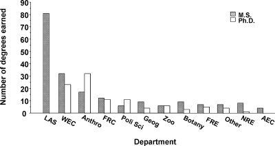

**Figure 2**

*Degrees earned by academic unit of Tropical Conservation and Development program alumni (LAS, Latin American Studies; WEC, Wildlife Ecology and Conservation; Anthro, Anthropology; FRC, Forest Resources and Conservation; Poli Sci, Political Science; Geog, Geography; Zoo, Zoology; FRE, Food and Resource Economics; NRE, Natural Resources and the Environment; and AEC, Agricultural Education and Communication).*

The TCD program has never aspired to become a degree-granting program; rather, it complements and builds on the traditional disciplinary education received in affiliated academic units across campus. Because it is housed in University of Florida's Center for Latin American Studies, without allegiance to any particular college, TCD enjoys a level of autonomy and neutrality that has fostered experimentation and development of unique mechanisms that support learning and action.

An important result of the program is the intellectual heterodoxy and innovation that emerge from cross-disciplinary dialogue. Rather than seeking an overarching theory or unitary model, the program fosters discussion of key concepts or problems from many different perspectives. This approach to understanding system change emphasizes its cross-scale, dynamic, discontinuous nature, based on the interplay between change and persistence, predictability, and unpredictability (Holling et al. 2002). Students and faculty draw on an array of theoretical works that link natural and social systems such as resilience, adaptive management, and political ecology (e.g., Blaikie & Brookfield 1987; Lee 1993; Gunderson & Holling 2002) and learning theories grounded in adult education and social learning (e.g., Knowles 1980; Freire 1993; Buck et al. 2001).

#### PERSONAL-LEADERSHIP FOCUS

A second dimension of the TCD learning and action platform is development of skilled and creative leaders (Fig. 1) by building on the diversity of leadership potential and styles that exists among the students. Graduate students in the program typically bring with them an impressive amount of experience. Many are returning to school after having been key members of a research team or having worked with conservation programs in the field or with rural communities through programs such as the U.S. Peace Corps. Respondents of a 2004–2005 TCD student survey (*n*= 44) had a mean age of 32 years, and more than 63% had between 1 and 6 years of work experience. Another 30% had more than 7 years of experience. The TCD program taps into these experiences and those garnered in graduate school, consciously creating a space where students can reflect on and contextualize their experiences, skills, and knowledge, solidifying their learning and strengthening leadership abilities.

Traditionally graduate students are trained to develop and sharpen technical skills essential for becoming a rigorous researcher. Within the TCD program the emphasis is on developing other complementary skills critical for those working at the conservation and development interface: learn outside their immediate disciplines, think in terms of linked socioecological systems, work in teams, negotiate among competing interests, communicate in nonacademic formats, and reflect critically on their own perspectives and actions. In this model, faculty not only act as experts or keepers of knowledge but also assume the role of facilitating learning rather than controlling it. Students are expected to take greater responsibility for their own learning (given that adults learn most effectively when they are encouraged to participate in and direct their own learning), build on what they already know, and discover and define what they need to know (Heron 1999).

#### FIELD-APPLICATION FOCUS

The third leg of the TCD platform focuses on field application of the accumulated skills and knowledge (Fig. 1). This can also be called *praxis*, which Vella (1995) defines as “practice with reflection.” This praxis component incorporates student interactions with TCD's myriad institutional partners in Latin America and elsewhere, promoting collaborative learning and practice and building an international and transgenerational commitment to tropical conservation and development. Students learn to juggle different expectations and often competing roles as they negotiate the focus and approach of their research with academic committee members, host-country university and NGO partners, and local communities. They are then encouraged and supported to return the results of their research in forms useful to these partners.

The TCD alumni represent more than 30 countries, but most foreign graduates are from Latin America (Fig. 3). This distribution reflects the program's long-term commitment to a learning and action network with field-based partners, especially in certain countries such as Brazil, Bolivia, and Peru, where TCD faculty have strong ties. It also conforms to the mandates of the TCD program's endowment, which requires that most of the fellowships be awarded to students from Latin America or the Caribbean.

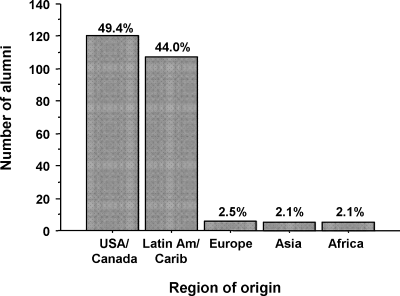

**Figure 3**

*Region of origin of the Tropical Conservation and Development program alumni.*

Current students typically integrate their studies within a larger TCD alumni and partner network, developing research that is meaningful, relevant, and more effective in addressing real-world problems. Certainly, this approach is messy, but students learn to develop, negotiate, carry out, and share their research with local partners in tropical countries. This type of continuous dialogue and deliberation among scientists, planners, managers, and natural-resource users is necessary to explore complex problems and solutions—a major premise behind social learning (Buck et al. 2001).

The TCD platform of theory, skills, and praxis creates an intellectual, social, and professionally safe space for students, faculty, and other TCD participants to creatively address the complex challenges of tropical conservation and development. This philosophical approach to graduate education calls for an attitude of openness to disciplinary cross-fertilization, a commitment to conservation and human rights, and a willingness to reflect and learn from one's mistakes and the experiences of others. The program also seeks to engender an atmosphere of trust among students and between students and professors for the open expression of ideas, which includes placing a high value on listening and respect.

Change is also inherent within this learning and action platform given its multifaceted connections to a larger context of disciplinary foundations from faculty in participating departments, student experience, and the TCD learning and action network, elements that feed into the program (Fig. 1). One can also think of the platform as an organic system in which these external elements highlighted in the framework provide inputs into the platform and change with the outputs of the program as it constantly evolves.

## Putting TCD into Practice

What are some of the practical ways in which the TCD program puts this approach into practice? Rather than creating a formal degree program, TCD concentrates on developing a complementary set of activities (courses, workshops, conferences, fellowships, research grants, and visitors) that are open to students from throughout the university who share an interest in tropical conservation and development. The three central goals (training, research, and promotion of a learning and action network) are blended together in practice such that most programmatic decisions are based on consideration of how a particular decision might maximize gain in each of these three areas. Development of the program's three core courses is a good example of this approach.

### Coursework

The first core course in the 1980s was an interdisciplinary seminar on the Amazon region, which combined history, ecology, and development studies to focus on problems of deforestation, biodiversity conservation, and sustainable development. This prototype conceptual course evolved into different courses that are typically taught by a team of social and biological scientists who introduce key concepts and theories from the social and biophysical sciences to address central problems and issues from a comparative perspective across multiple scales in time and space. For example, a course currently offered (Community Forest Management) covers ecosystems, disturbance, and biodiversity; communities and institutions; social learning and adaptive management; forest management for timber, nontimber, and environmental services; monitoring and evaluation; and ethics and social responsibility (http://www.sfrc.ufl.edu/class/for6934/). This course often invites select students to deliver course-relevant sessions, drawing extensively on student experience and expertise. As with other core TCD courses, student feedback is solicited formally through written and oral evaluations. These evaluations exemplify TCD's emphasis on continuous critical learning, improve the course, serve to keep teaching fresh and enthusiastic, and offer students a stake in the course and larger program. These approaches diminish the role of the professor as expert and implement the teaching philosophy of facilitating rather than controlling learning.

The second core course focuses on research design and methods for students interested in carrying out applied and interdisciplinary research (http://www.wec.ufl.edu/faculty/brunae/LAS6292.htm). Also taught by a team of social and biological scientists, the course covers paradigms for scientific inquiry, experimental design and methods, and the administration of research projects. To develop skills in these areas, students are required to develop a research proposal; they identify the issue, develop testable hypotheses to address it, and propose a suite of methods to test their hypotheses. Each proposal is then critiqued by students from both the natural and social sciences, who propose additional methods. Students revise their proposals accordingly and teach the other course participants some of the methods they will use. Finally, students conduct a group conservation and development course project, which allows them to develop their skills in project design, administration, and collaborative work.

The third set of TCD core courses focuses on conservation and development skills. This course recognizes that many TCD graduates work as field practitioners and academic researchers and seek explicit training in practical skills development. Course content varies depending on the instructor, and current course options include Facilitation Skills for Adaptive Management (http://www.latam.ufl.edu/people/NEW%20PEOPLE%20PAGES%20UPDATES/Info/DainSyllabusLAS6291Facilitation.pdf), Conservation Entrepreneurship, and Collaboration and Conflict Management for Conservation and Development (http://www.latam.ufl.edu/people/NEW%20PEOPLE%20PAGES%20UPDATES/Info/DainSyllabusLAS6921Conflict.pdf). Although these courses examine theoretical frameworks much like other graduate courses, the focus is on learning and practicing the communication, facilitation, negotiation, mediation, and management skills needed by conservation and development professionals in the real world. Subsequently, students who take these courses are often tapped to organize on-campus training sessions and workshops. They may also develop off-campus activities with partner institutions through the practitioner experience described below or through a paid consultancy. With faculty “backstopping,” these concrete opportunities incrementally build and refine students' skills and simultaneously develop new and strengthen existing linkages between TCD and field partners.

### Alternative Learning and Action Spaces

Although the core courses are central to the certification curriculum, the hallmark of the TCD graduate education program is the multiple learning opportunities outside the classroom, what we call alternative learning spaces. These spaces may focus on information giving and exchange but often place a premium on processing and reflecting on one's perspectives and actions. They are also key elements for training professionals capable of responding more effectively to the complexity of real-world conservation and development needs.

The program's field-research grants competition is a good example of this type of learning and action space. Between 1988 and 2005, 227 grants were awarded for students to work in 33 foreign countries on projects ranging from evaluating collaborative management projects in Uganda to studying the evolutionary ecology and conservation of Neotropical birds. This annual grants competition supports student projects and encourages interaction with partners in the field. Graduate students compete for the awards based on sound scientific proposals that are judged by an interdisciplinary faculty panel. In addition, they negotiate their focus and research approach with field partners and communities in the countries of their research. Each student is affiliated with a local organization and uses written protocols for collaboration when possible. Recipients are required to develop ways to return their research results to partner groups through locally appropriate formats such as workshops, technical brochures, or seminars. Similarly, they are expected to share their findings and experiences with others at the University of Florida in an annual TCD field research clinic, which includes a poster competition and student discussion groups.

The TCD program also offers funds for “practitioner experiences,” a form of internship in which students work with a host organization, learning from them and contributing to the organization's efforts. Practitioner experiences might include organizing a workshop, returning research results to host country partners and communities, or assisting in project planning, implementation, or evaluation. Recent practitioner experiences include full participation on a technical evaluation team for World Wildlife Fund forest-based projects in Suriname and Guyana, facilitation of a partner-driven workshop in Mexico on recent developments in mahogany research, and dissemination of ecotourism and protected area land-use-change research results to partner organizations and communities in Belize and Brazil, respectively. Through this program, TCD has provided direct educational benefits to graduate students and to partner institutions, communities, and researchers.

Another opportunity for alternative, outside-the-classroom learning and action is through visiting professionals who come to campus from partner organizations. Visitor goals are diverse and include, for example, joint development of a research proposal or use of the campus libraries. They usually also conduct a training workshop, however, or deliver a session within a TCD course on a particular skill or approach of interest to students. While advancing their own professional goals and keeping the TCD program current, these visitors become part of the TCD learning and action platform and create a space where students can learn from field personnel entrenched in day-to-day conservation and development realities.

Other examples of alternative learning spaces include orientations and retreats, a weekly student-led seminar series and periodic workshops, a predeparture (field research) workshop, and a proposal-writing workshop. These are integrated into the TCD program and are considered key to fulfilling the program's goals. These alternative learning spaces do not add unnecessary course requirements to an already-packed graduate curriculum. Student response to these activities has been overwhelmingly positive, and evaluations indicate students find them extremely helpful in supporting their immediate graduate-study needs and giving them a broader perspective on their professional roles.

These alternative spaces also encourage students to take charge of their own learning, drawing on their training and experiences. For example, teams of TCD students have organized and led multiple one-half-day or one-day workshops to share their disciplinary expertise in such diverse topics as ecological concepts for social scientists, gender analysis targeting natural scientists, and basic geographic information system skills for the nonexpert. Student-led workshops are another forum in which student leaders practice and fine-tune their skills. Their peers consistently give these workshops high marks. Backstopping by TCD faculty is key to the success of these workshops, ensuring that those students on the delivery end have sufficient support and those on the receiving end get a good product.

Learning and action spaces are not only for students, and are considered central to program development. The TCD program places a high value on systematically and thoroughly evaluating and reflecting on its activities, be they graduate courses, new programmatic efforts, or student orientations and retreats. This type of learning is sometimes termed *double-loop learning* (Buck et al. 2001) or *transformative learning*, in which one learns about learning processes in order to improve them. It is transformative because by incorporating periodic and systematic evaluation of the learning process, one is forced to critique fundamental principles and habits of doing work, often transforming or changing one's knowledge base, skills, and attitudes. An example of this double-loop learning within TCD is the end-of-semester faculty retreats organized to discuss teaching and other program activities. Similarly, student input on program activities and strategies is solicited regularly to delineate new ideas and outline corrective action. Another learning example is the conference on “New Horizons, New Challenges in Tropical Conservation and Development” which brought together TCD students, faculty, and alumni in 2002 to consider the future of the field. These critical moments of reciprocal learning continue to change and improve the way TCD carries out its graduate training. They also demonstrate the value of student input and collaboration, fostering trust within the program and mutual respect between students and faculty.

### Program Challenges

This “learning and action” approach to tropical conservation and development training begets new challenges for graduate education. The praxis elements of the program with explicit requirements to collaborate with home-country partners and return research results to local audiences create an additional set of demands on graduate students, by redefining good research. We currently have no evidence that TCD students take longer to complete their graduate degrees, but the academic certificate program is newly implemented and we are monitoring this important aspect. Service demands on TCD faculty are also elevated as they seek funds for and administer new programs to support collaborative field efforts and alternative educational opportunities. In addition, faculty time and energy needed to build and maintain the necessary long-term, long-distance relationships with partners are significant and typically not rewarded within the traditional academic system. Although many disciplinary advisors welcome the complementary support TCD provides their students, the program can be viewed as a hindrance to graduate studies given the course requirements, muddying of disciplinary waters, and the general uncertainties and trade-offs that typically accompany working closely with host-country partner institutions. Other persistent challenges particular to foreign students include English language requirements and student visa acquisition since 9/11. Many innovative and experienced tropical conservation and development workers have limited access to English-language training. Yet, it is precisely these alumni from foreign countries who most often have had the greatest impact when returning to their home countries.

### Student Perceptions and Program Impacts

The program was evaluated from a student perspective during the 2004-2005 academic year. A Web-based survey of current students and recent alumni provided quantitative data, and two subsequent focus groups with current students allowed for in-depth discussion of key topics. Only students who had taken at least one core course and were enrolled in or had completed the TCD program were invited to participate (*n*= 61). The response rate for the survey was 72%, and 16 students attended the focus group discussions. Key findings were that students strongly agree or agree that TCD provided them with opportunities to interact with and learn from professors and students outside their home department (97%); provided courses that offer a balance between theory, applied knowledge, and skills (91%); helped improve their skills in communication (82%), critical thinking (86%), and understanding of the roles of scale and complexity in social and ecological systems (84%); helped them develop a research project that better reflected the realities of their research site (81%); contributed to their professional growth directly (89%); and provided contacts that would be a part of their professional network (88%). Focus groups revealed that TCD provides important academic, personal, and professional support to students, with the international students stressing that the sense of community fostered was critical to their adaptation and learning. Students underscored that TCD is an ideal forum for bringing the disciplines together to foster discussion. They also highlighted the long-term benefits of learning to work with multicultural and interdisciplinary groups.

This student assessment emphasized that TCD facilitates formation of a network of people dedicated to tropical conservation and development. Indeed, the program's collaborative learning and action network is intended to create a critical mass that can significantly change the existing paradigm for conservation and development. At the heart of this network are TCD alumni and long-term partners with great disciplinary and geographic diversity, many of whom now hold key conservation and development positions. An analysis of the career paths chosen by TCD graduates supports this conclusion. Although a plurality of TCD alumni (27%) work in university settings, most have chosen a career outside academia (Fig. 4). These graduates work for nongovernmental organizations, advise philanthropic and multilateral institutions, serve in the governments of their home countries, or work as private consultants. Another 17% are currently pursuing additional advanced degrees. Perhaps most important, many alumni have returned to their home countries and are themselves actively engaged in teaching and training conservation professionals.

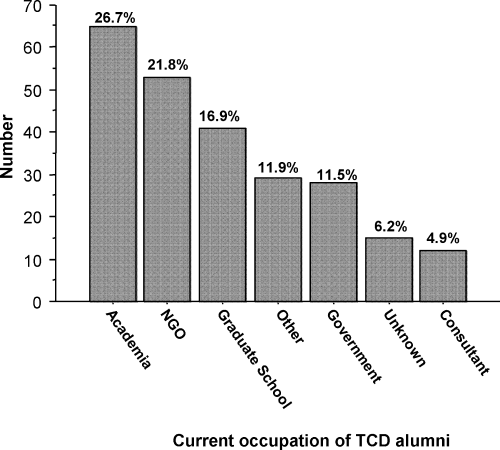

**Figure 4**

*Current occupation of the Tropical Conservation and Development program alumni.*

## Challenges and Opportunities Ahead

It is clear that urgent challenges to global conservation and development require new ways of thinking and learning. Despite some local success stories, social and environmental conditions have declined worldwide. In response, some scientists have resurrected a protected-areas agenda that removes humans from the conservation equation (Oates 1999; Terborgh 1999). Social activists may emphasize improving human welfare, regardless of the ecological cost, whereas other practitioners fear that conservation priorities are being completely subsumed under development goals such as poverty alleviation (Sanderson 2002).

Our experience suggests that, rather than retreating from developing innovative strategies to integrate conservation and development, current trends dictate the need for far greater creativity in addressing them simultaneously. To do so requires contributing to a paradigm shift in how humans are conceptualized in relation to the biophysical environment and how people are prepared for the technical and political leadership required to face the future. It appears that this paradigm shift is well under way. There is a growing understanding of humans as much more than simple disturbance agents in ecosystems and an appreciation of their complex and changing role throughout history. The shift toward viewing the entire planet as a human ecosystem has profound implications for a range of disciplines and policy making: both biological ecology and human ecology have become much more complicated.

We are also witnessing a gradual but accelerating crumbling of disciplinary boundaries. It is becoming increasingly common to let the problem dictate the fields of inquiry, rather than the discipline determining what problems are appropriate for investigation. The result has been the emergence of new fields (e.g., conservation biology) and shifts in priorities, especially in research funding. For example, the National Science Foundation (NSF) has dramatically increased funding for “cross-cutting initiatives” that require multiple disciplines oriented around a problem. Human-environment concerns have figured prominently in these initiatives, such as the Coupled Natural and Human Systems component of the Biocomplexity initiative and more recently in the Human and Social Dynamics competition. Meanwhile, funding increases for most disciplinary programs in NSF have remained minimal if not stagnant. This is a clear indication that although disciplines will continue to figure prominently in academia, interdisciplinary pursuits are on the rise.

There also is a growing recognition of the need to develop students' nonacademic professional skills to address better the complex challenges of conservation and development. The TCD program appreciates the crucial difference that can be made by individuals who are well prepared to innovate, negotiate, and integrate research and action for conservation and sustainable development. The most effective way to do so is through a praxis-oriented program that builds consciously on the experience of students, promotes critical self-reflection, and links research to real-world people and problems.

A welcome trend is occurring in the south-north dynamics of conservation and development leadership. There is a distinct shift away from U.S. and European hegemony in Southern Hemisphere investigations as research programs by tropical scientists increase, along with the negotiation of successful north-south initiatives that are truly collaborative. Likewise, the environmental movement has gained momentum in tropical countries and has emerged with a keen eye to the reconciliation of local, immediate needs and long-term conservation, rather than the acrimonious, polar separation of conservation and development that too often transpires in the north. Parallel to these positive south-north shifts is the emergence of academic programs that integrate conservation and development in Mexico, Brazil, and other Latin American countries. These growing interdisciplinary programs, coupled with adaptive educational approaches that emphasize learning and action networks of students, faculty, and a range of partners, provide the best hope for responding to the emerging challenges of tropical conservation and development.

## Citing Literature

[Volume20, Issue1](https://conbio.onlinelibrary.wiley.com/toc/15231739/2006/20/1)

February 2006

Pages 3-13